# Classification

Elbrus Gasimov, Guunnet Singh

5/31/2021

### Importing the required packages and libraries

```r
#install.packages(c('ROCR','ggplot2','corrplot','caTools','class',
#                   'randomForest','pROC','imbalance'))
library(ROCR)
library(ggplot2)
library(corrplot)
library(caTools)
library(class)
library(randomForest)
library(pROC)
library(imbalance)
library(rpart)
```

# The data is saved as a csv file namely creditcard.csv

# About the Dataset:

The dataset includes 284807 observations and 31 variables. Out of these 31 variables, one variable (Class) is the variable of interest. The dataset contains transactions made by credit cards in September 2013 by European cardholders over a span of two days. Due to confidentiality issues, dataset contains only numerical input variables which are the result of a PCA transformation. Only features which have not been transformed with PCA are ‘Time’ and ‘Amount’. Feature ‘Time’ contains the seconds elapsed between each transaction and the first transaction in the dataset. The feature ‘Amount’ is the transaction Amount.

##Basic Exploratory Data Analysis

Viewing some initial observations of the dataset

```r
head(transaction)
```

```
##   Time         V1          V2        V3         V4          V5          V6
## 1    0 -1.3598071 -0.07278117 2.5363467  1.3781552 -0.33832077  0.46238778
## 2    0  1.1918571  0.26615071 0.1664801  0.4481541  0.06001765 -0.08236081
## 3    1 -1.3583541 -1.34016307 1.7732093  0.3797796 -0.50319813  1.80049938
## 4    1 -0.9662717 -0.18522601 1.7929933 -0.8632913 -0.01030888  1.24720317
## 5    2 -1.1582331  0.87773675 1.5487178  0.4030339 -0.40719338  0.09592146
## 6    2 -0.4259659  0.96052304 1.1411093 -0.1682521  0.42098688 -0.02972755
##            V7          V8         V9         V10        V11         V12
## 1  0.23959855  0.09869790  0.3637870  0.09079417 -0.5515995 -0.61780086
## 2 -0.07880298  0.08510165 -0.2554251 -0.16697441  1.6127267  1.06523531
## 3  0.79146096  0.24767579 -1.5146543  0.20764287  0.6245015  0.06608369
## 4  0.23760894  0.37743587 -1.3870241 -0.05495192 -0.2264873  0.17822823
## 5  0.59294075 -0.27053268  0.8177393  0.75307443 -0.8228429  0.53819555
## 6  0.47620095  0.26031433 -0.5686714 -0.37140720  1.3412620  0.35989384
##          V13        V14        V15        V16         V17         V18
```

[output cut: 20 more lines]

## Viewing Structure of transactions

```r
str(transaction)
```

```
## 'data.frame':    284807 obs. of  31 variables:
##  $ Time  : num  0 0 1 1 2 2 4 7 7 9 ...
##  $ V1    : num  -1.36 1.192 -1.358 -0.966 -1.158 ...
##  $ V2    : num  -0.0728 0.2662 -1.3402 -0.1852 0.8777 ...
##  $ V3    : num  2.536 0.166 1.773 1.793 1.549 ...
##  $ V4    : num  1.378 0.448 0.38 -0.863 0.403 ...
##  $ V5    : num  -0.3383 0.06 -0.5032 -0.0103 -0.4072 ...
##  $ V6    : num  0.4624 -0.0824 1.8005 1.2472 0.0959 ...
##  $ V7    : num  0.2396 -0.0788 0.7915 0.2376 0.5929 ...
##  $ V8    : num  0.0987 0.0851 0.2477 0.3774 -0.2705 ...
##  $ V9    : num  0.364 -0.255 -1.515 -1.387 0.818 ...
##  $ V10   : num  0.0908 -0.167 0.2076 -0.055 0.7531 ...
##  $ V11   : num  -0.552 1.613 0.625 -0.226 -0.823 ...
##  $ V12   : num  -0.6178 1.0652 0.0661 0.1782 0.5382 ...
##  $ V13   : num  -0.991 0.489 0.717 0.508 1.346 ...
```

[output cut: 17 more lines]

```r
sapply(transaction, FUN=class)
```

```
##      Time        V1        V2        V3        V4        V5        V6        V7
## "numeric" "numeric" "numeric" "numeric" "numeric" "numeric" "numeric" "numeric"
##        V8        V9       V10       V11       V12       V13       V14       V15
## "numeric" "numeric" "numeric" "numeric" "numeric" "numeric" "numeric" "numeric"
##       V16       V17       V18       V19       V20       V21       V22       V23
## "numeric" "numeric" "numeric" "numeric" "numeric" "numeric" "numeric" "numeric"
##       V24       V25       V26       V27       V28    Amount     Class
## "numeric" "numeric" "numeric" "numeric" "numeric" "numeric" "integer"
```

## After the basic data exploration we found that all of the variables including

the target variable are of numeric data type, due to the PCA.

##Viewing the Frequency distribution of “Class” Variable

```r
table(transaction$Class)
```

```
##
##      0      1
## 284315    492
```

```r
prop.table(table(transaction$Class))
```

```
##
##           0           1
## 0.998272514 0.001727486
```

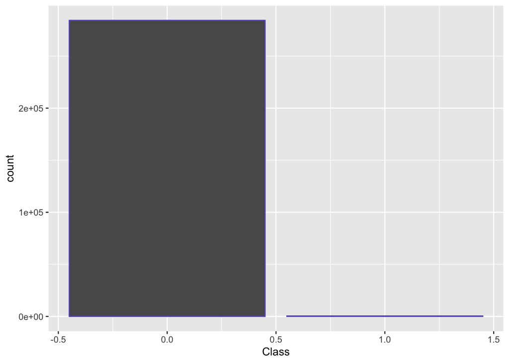

```r
ggplot(data = transaction,aes(x=Class))+geom_bar(col="slateblue3")
```

##The dataset is highly imbalanced, the positive class (frauds) account for mere 0.172% of all transactions. This is really good for the credit card company but not for this analysis.

# Plotting the Amount - Fraud chart

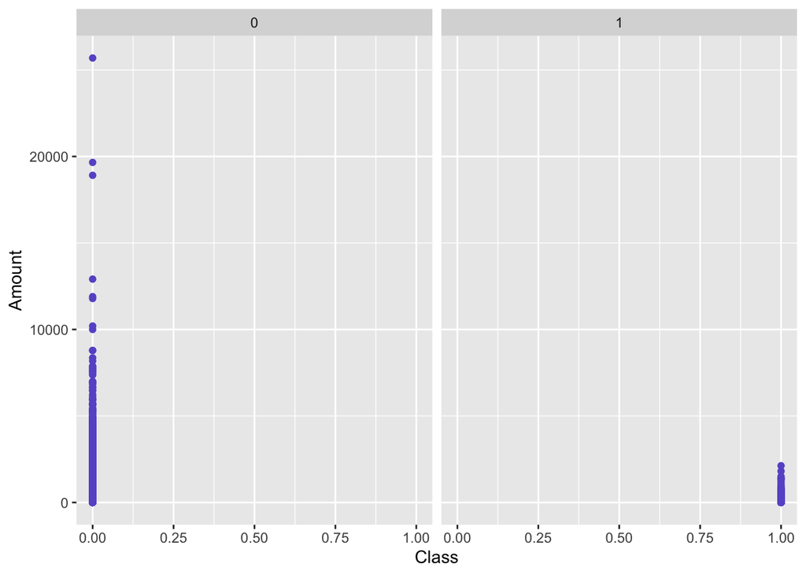

```r
ggplot(data = transaction,aes(y=Amount,x=Class))+geom_point(col="slateblue3") +
  facet_grid(~Class)
```

##This plot tells us that all the fraudulent transactions were made for less ##than around 2500, which is considerably less than that of true transactions.

# Exploring Time Column with Regards to the Class variable

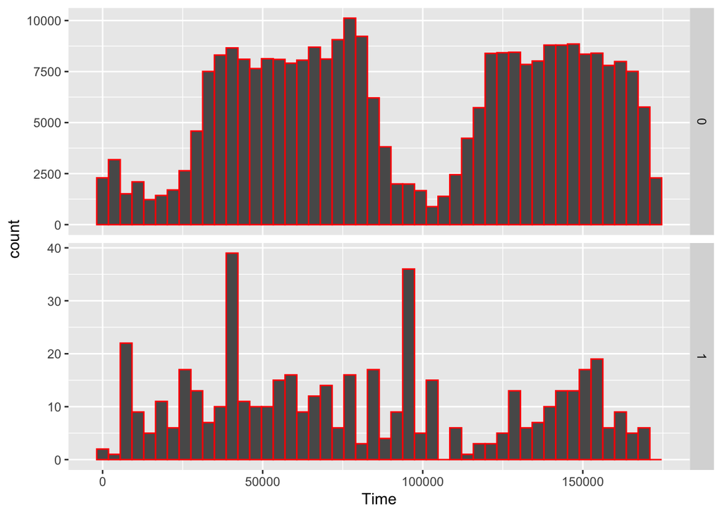

```r
ggplot(data = transaction,aes(x=Time),fill=factor(Class))+
  geom_histogram(col='red',bins=48) +  facet_grid(Class ~ ., scales = 'free_y')
```

## As the unit of measure for Time here is seconds, it makes it harder to

## understand and get anything useful out of this.

# Converting Time(Seconds) into Hours for better understanding

```r
transaction$hours <- round(transaction$Time/3600)
unique(transaction$hours)
```

```
##  [1]  0  1  2  3  4  5  6  7  8  9 10 11 12 13 14 15 16 17 18 19 20 21 22 23 24
## [26] 25 26 27 28 29 30 31 32 33 34 35 36 37 38 39 40 41 42 43 44 45 46 47 48
```

# Checking correlation between the variables

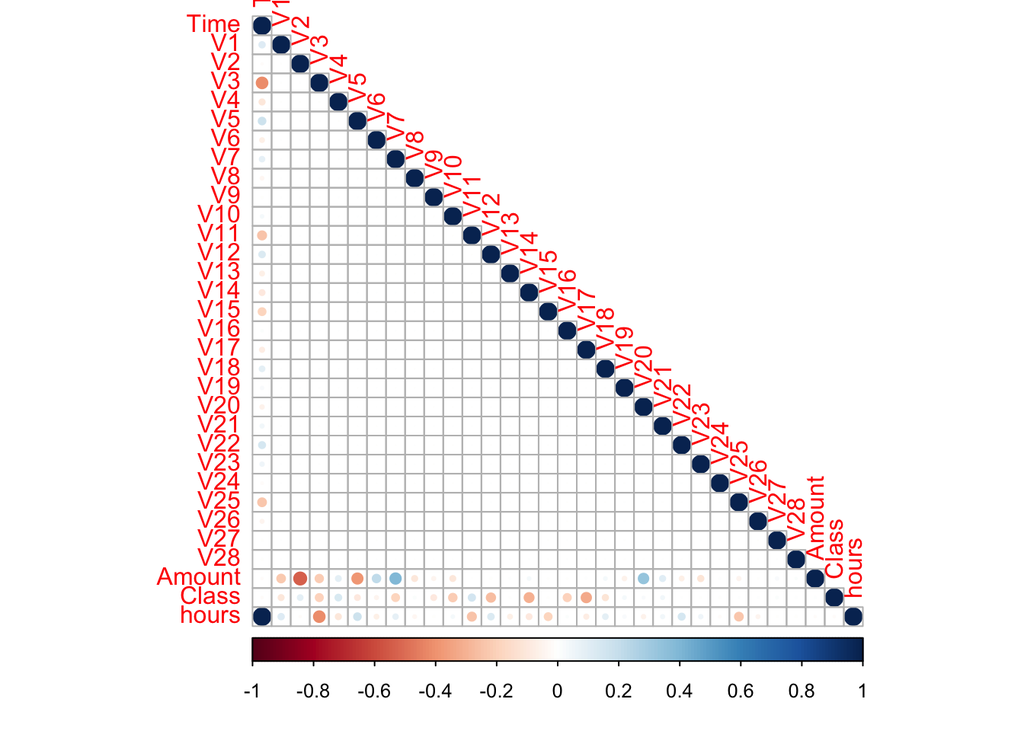

```r
transaction$Class <- as.numeric(transaction$Class)
corr <- cor(transaction[],method="pearson")
corrplot(corr,method = "circle", type = "lower")
```

# This shows that there is not much correlation among the variables.

## “V2” has some negative correlation with “Amount”. However, we can ignore it.

## Converting “Class” to factor type for Modeling purposes

```r
transaction$Class <- as.factor(transaction$Class)
```

# Splitting the dataset into the Training dataset and Test dataset

##We are doing 75-25 split..

```r
# For reproducability of the random selection
set.seed(123)
```

## We are using sample.split and subset functions from caTools Library to split

## the data randomly

```r
split = sample.split(transaction$Class, SplitRatio = 0.75)
training_set = subset(transaction, split == TRUE)
test_set = subset(transaction, split == FALSE)
```

# Verify if the proportion of Class is still the same

```r
table(training_set$Class)
```

```
##
##      0      1
## 213236    369
```

```r
prop.table(table(training_set$Class))
```

```
##
##           0           1
## 0.998272512 0.001727488
```

```r
table(test_set$Class)
```

```
##
##     0     1
## 71079   123
```

```r
prop.table(table(test_set$Class))
```

```
##
##          0          1
## 0.99827252 0.00172748
```

## To balance out the minority(fraud) and majority class in dataset, we are using

## the SMOTE technique. We are setting ratio at 0.8 which means we are

## oversampling our minority class to come upto 80% of the majority class.

## It will maintain the ratio and the machine learning model will now be able to

## easily understand the minority class also.

```r
smoted_training_set<-oversample(dataset= training_set,
                                method = 'SMOTE',ratio = 0.8)
table(smoted_training_set$Class)
```

```
##
##      0      1
## 213236 170589
```

```r
prop.table(table(smoted_training_set$Class))
```

```
##
##         0         1
## 0.5555553 0.4444447
```

```r
colnames(smoted_training_set)
```

```
##  [1] "Time"   "V1"     "V2"     "V3"     "V4"     "V5"     "V6"     "V7"
##  [9] "V8"     "V9"     "V10"    "V11"    "V12"    "V13"    "V14"    "V15"
## [17] "V16"    "V17"    "V18"    "V19"    "V20"    "V21"    "V22"    "V23"
## [25] "V24"    "V25"    "V26"    "V27"    "V28"    "Amount" "Class"  "hours"
```

# Excluding the Class variable to calculate the scaled values for each columns

```r
smoted_training_set[-31] <- scale(smoted_training_set[-31])
test_set[-31] <- scale(test_set[-31])
```

# Fitting Logistic Regression to the Training set

```r
classifier <- glm(formula = Class ~ .,
                  family = binomial,
                  data = smoted_training_set)
summary(classifier)
```

```
##
## Call:
## glm(formula = Class ~ ., family = binomial, data = smoted_training_set)
##
## Deviance Residuals:
##     Min       1Q   Median       3Q      Max
## -8.4904  -0.1388  -0.0265   0.0000   3.2481
##
## Coefficients:
##             Estimate Std. Error z value Pr(>|z|)
## (Intercept) 19.87614    0.27953  71.106  < 2e-16 ***
## Time         7.46084    0.60292  12.375  < 2e-16 ***
## V1           7.00025    0.13672  51.203  < 2e-16 ***
## V2           4.51192    0.15677  28.780  < 2e-16 ***
## V3           4.30473    0.12788  33.661  < 2e-16 ***
## V4           2.32649    0.04618  50.381  < 2e-16 ***
## V5           5.49281    0.12496  43.958  < 2e-16 ***
## V6          -1.41290    0.03574 -39.528  < 2e-16 ***
## V7          -7.53785    0.22080 -34.138  < 2e-16 ***
## V8          -1.88590    0.07891 -23.898  < 2e-16 ***
## V9          -0.95406    0.04560 -20.923  < 2e-16 ***
## V10         -4.08212    0.10712 -38.109  < 2e-16 ***
## V11          2.78667    0.04585  60.779  < 2e-16 ***
## V12         -7.49424    0.09940 -75.392  < 2e-16 ***
## V13         -0.70719    0.01347 -52.507  < 2e-16 ***
## V14         -9.69955    0.11086 -87.495  < 2e-16 ***
## V15         -0.26425    0.01370 -19.292  < 2e-16 ***
## V16         -2.85309    0.08585 -33.235  < 2e-16 ***
## V17         -9.83613    0.16907 -58.179  < 2e-16 ***
## V18         -2.02368    0.05667 -35.708  < 2e-16 ***
## V19          0.85941    0.02247  38.252  < 2e-16 ***
## V20         -1.18016    0.03991 -29.567  < 2e-16 ***
## V21          0.08597    0.04927   1.745  0.08099 .
## V22          1.03663    0.02749  37.711  < 2e-16 ***
## V23          1.26896    0.03831  33.122  < 2e-16 ***
## V24          0.03943    0.01424   2.769  0.00562 **
## V25          0.16188    0.01783   9.081  < 2e-16 ***
## V26          0.07801    0.01341   5.819 5.91e-09 ***
## V27          0.31410    0.04296   7.311 2.64e-13 ***
## V28          0.63705    0.02379  26.782  < 2e-16 ***
## Amount       3.31546    0.08711  38.061  < 2e-16 ***
## hours       -7.69645    0.60390 -12.745  < 2e-16 ***
## ---
## Signif. codes:  0 '***' 0.001 '**' 0.01 '*' 0.05 '.' 0.1 ' ' 1
##
## (Dispersion parameter for binomial family taken to be 1)
##
##     Null deviance: 527346  on 383824  degrees of freedom
## Residual deviance:  45459  on 383793  degrees of freedom
## AIC: 45523
##
## Number of Fisher Scoring iterations: 15
```

## higher than the 5% level of significance.

## Predicting the Test set results

```r
prob_pred <- predict(classifier, type = 'response', newdata = test_set[-31])
```

## Setting a condition that even if there are more than 40% chances(>0.4) of

## getting a Fraud Transaction, model should predict it as Fraud.

```r
y_pred <- ifelse(prob_pred > 0.4, 1, 0)
```

## Calculating and Plotting the AUC-ROC curve

## AUC(Area under the curve) curve tells that how accurately our model is

## predicting together with its overall Performance.

## The thumb-rule is that Higher the AUC Better our model is at predicting.

```r
calc_auc <- function (prob_pred,test_y){
  predict_log <- prediction(prob_pred,test_y) # Prediction Probability

  #Calculating ROC Curve...
  table(test_y, prob_pred>0.4)
  roc_curve<- performance(predict_log,"tpr","fpr")
  # plot(roc_curve)
  plot(roc_curve, colorize=T)

  #Calculating AUC and printing....
  auc<- performance(predict_log,"auc")
  paste(auc@y.values[[1]])

}
```

# Make confusion matrix

```r
cm <- table(test_set[, 31], y_pred > 0.4)
cm
```

```
##
##     FALSE  TRUE
##   0  3737 67342
##   1     1   122
```

# Print AUC

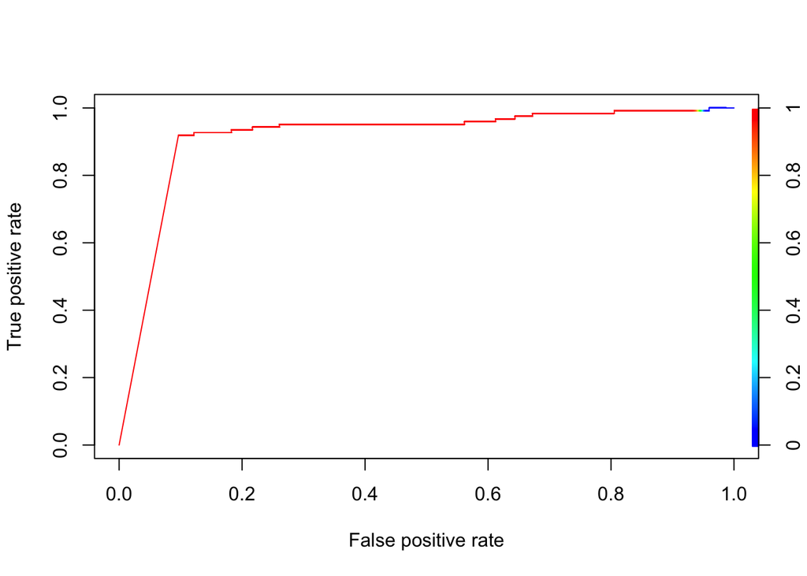

```
## [1] "0.914734344026896"
```

```r
print(calc_auc(prob_pred,test_set$Class))
```

# Creating Random Forest Model

## ntree = 100

```r
set.seed(123)
forest.classifier = randomForest(x = smoted_training_set[-31],
                                 y = smoted_training_set$Class,
                                 ntree = 100)
```

# Predicting Classes using the model

```r
forest.y_pred = predict(forest.classifier, newdata = test_set[-31])
```

# Predicting Probabilities

```r
forest.y_prob = predict(forest.classifier, newdata = test_set[-31], type='prob')
```

# Predicting Log for AUC Generation

```r
forest.predict_log <- prediction(as.numeric(y_pred),as.numeric(test_set$Class))
```

# Calculating AUC Curve

```r
forest.auc<- performance(forest.predict_log,"auc")
print( (forest.auc@y.values[[1]]))
```

```
## [1] 0.5222226
```

# Making the confusion matrix

```r
cm <- table(test_set[, 31], forest.y_pred)
cm
```

```
##    forest.y_pred
##         0     1
##   0 58012 13067
##   1    27    96
```

# Creating AUC ROC Curve

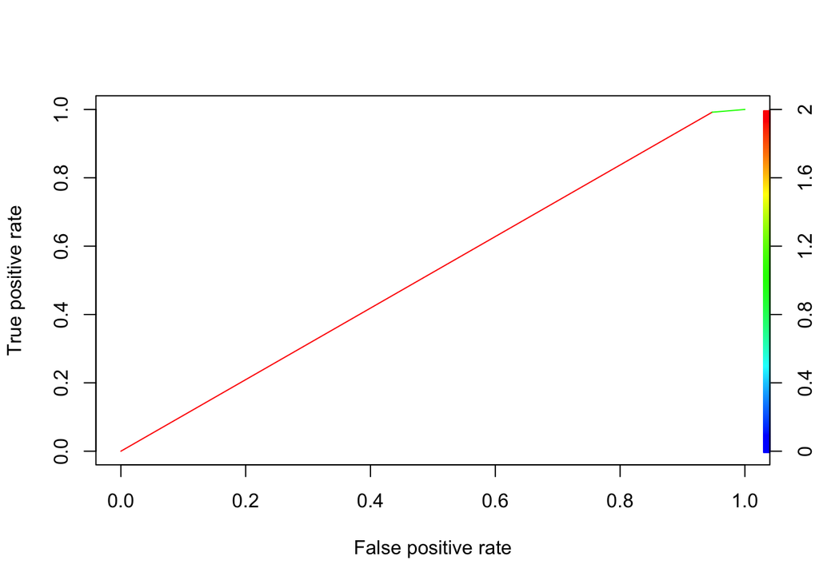

```r
roc_curve<- performance(forest.predict_log,"tpr","fpr")
plot(roc_curve, colorize=T)
```

# Decision Tree Classifier

```r
tree.model <- rpart(Class~.,smoted_training_set,method='class')
tree.predict <- predict(tree.model, newdata = test_set[-31],type = 'class')
tree.predict_log <- prediction(as.numeric(tree.predict),
                               as.numeric(test_set$Class))
```

# Calculating AUC Curve

```r
tree.auc<- performance(tree.predict_log,"auc")
print( (tree.auc@y.values[[1]]))
```

```
## [1] 0.5479827
```

# Conclusions: